# The Beer Necessities

Team: Carly Seeck, Drew Hirsh, Eric Hedgren, Henry Eichten, Gavin Fisher

12/08/2023

### How does the Alcohol content of the beer affect its overall rating?

#### Summary Statistics

```r
summary(data$ABV)
```

```
##    Min. 1st Qu.  Median    Mean 3rd Qu.    Max.
##   0.000   5.000   6.000   6.527   7.600  57.500
```

```r
#Max ABV beer
max_abv <- max(data$ABV, na.rm = TRUE)
beer_with_max_abv <- data[data$ABV == max_abv, ]
beer_with_max_abv
```

```
##                 Name          Style      Brewery              Beer.Name..Full.
## 300 Schorschbock 57% Bock - Eisbock Schorschbräu Schorschbräu Schorschbock 57%
##     Description  ABV Min.IBU Max.IBU Astringency Body Alcohol Bitter Sweet Sour
## 300      Notes: 57.5      25      35           0    7      17      3     9    6
##     Salty Fruits Hoppy Spices Malty review_aroma review_appearance
## 300     0     10     0      2     4            4                 4
##     review_palate review_taste review_overall number_of_reviews
## 300             4          3.5              4                 1
```

- The minimum ABV in the data set was 0, meaning non-alcoholic beers were present.
- The 1st quartile was 5.0% ABV, meaning that 25% of beers have an ABV of 5.0% or less.
- The median was 6.0% ABV.
- The mean was 6.53% AVV.
- The 3rd quartile was at 7.6% ABV, meaning 75% of the beers have an ABV of 7.6% or less.
- The max ABV was 57.5% from the beer ‘Schorschbräu Schorschbock 57%’.

```r
cor(data$ABV, data$review_overall, use = "complete.obs")
```

```
## [1] 0.2518383
```

The correlation coefficient between ABV and overall rating is 0.251. This indicates a weak positive relationship between alcohol content and the overall rating. As the ABV increases, there will be a slight tendency for the overall rating to increase as well, but the relationship is not strong.

#### Plots

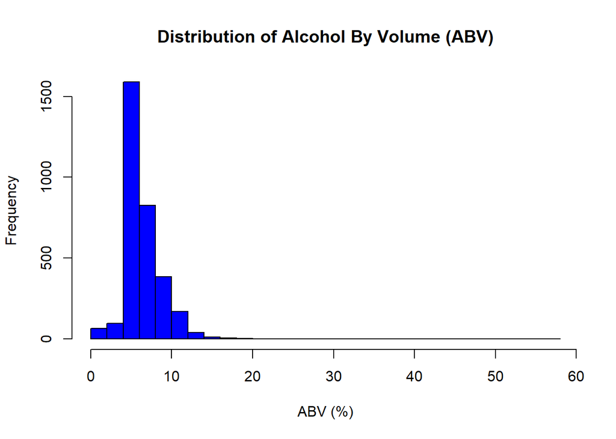

```r
#Histogram for ABV Distribution
hist(data$ABV, main="Distribution of Alcohol By Volume (ABV)",
     xlab="ABV (%)", ylab="Frequency", col="blue", breaks=30)
```

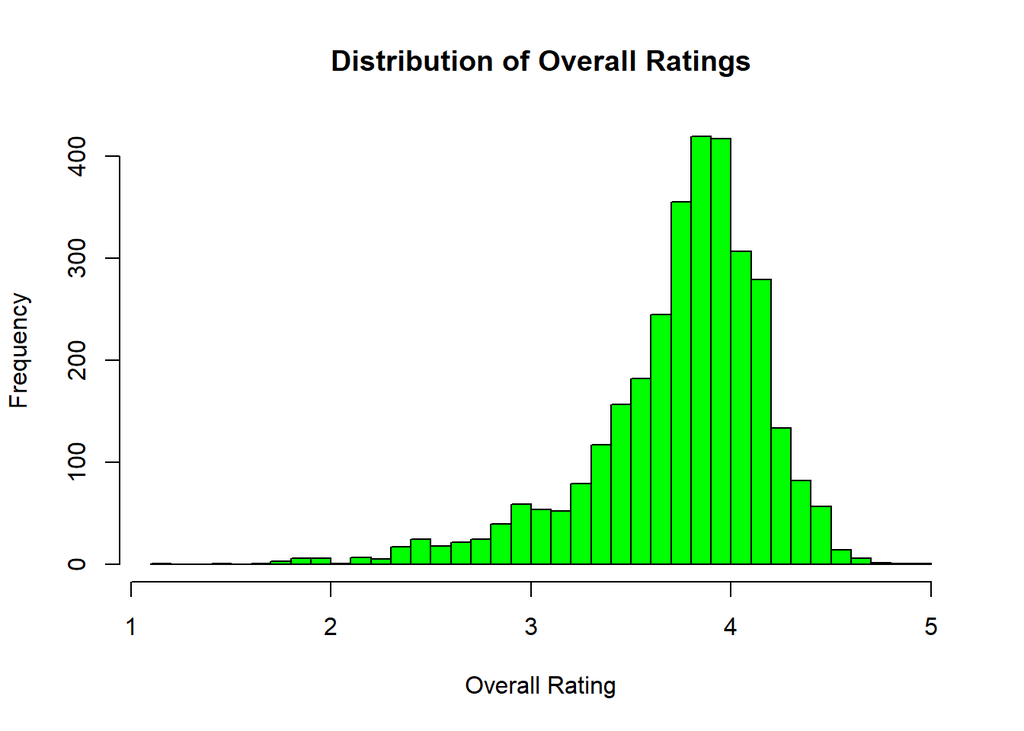

```r
# Histogram for Overall Ratings Distribution
hist(data$review_overall, main="Distribution of Overall Ratings",
     xlab="Overall Rating", ylab="Frequency", col="green", breaks=30)
```

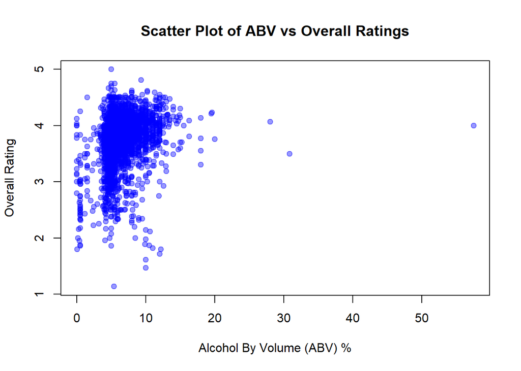

```r
# Scatter Plot
plot(data$ABV, data$review_overall, main="Scatter Plot of ABV vs Overall Ratings",
     xlab="Alcohol By Volume (ABV) %", ylab="Overall Rating", pch=19, col=rgb(0,0,1,0.4))
```

Interpretation of ABV vs Overall Rating - The scatter plot indicates that there is very little to no evidence to suggest a clear-cut influence of alcohol content on beer ratings. Other characteristics are likely more indicative of the overall ratings of the beer.

### Which Brewery has the highest rated beers?

#### Top 5 Breweries Overall

```
## # A tibble: 5 × 2
##   Brewery                                                    Rating
##   <chr>                                                       <dbl>
## 1 Helios Distillery Co., Ltd.                                  4.75
## 2 Brauerei Zehendner GmbH                                      4.63
## 3 The Alchemist                                                4.63
## 4 U Fleků Pivovaru a Restauraci                                4.52
## 5 Brouwerij Westvleteren (Sint-Sixtusabdij van Westvleteren)   4.50
```

#### Top 5 Breweries by Aroma

```
## # A tibble: 5 × 2
##   Brewery                   Rating
##   <chr>                      <dbl>
## 1 Hops & Grain                5
## 2 The Alchemist               4.66
## 3 Asheville Brewing Company   4.5
## 4 The Livery                  4.5
## 5 Dry Dock Brewing Co.        4.44
```

#### Top 5 Breweries by Appearance

```
## # A tibble: 5 × 2
##   Brewery                                                    Rating
##   <chr>                                                       <dbl>
## 1 Brasserie d'Orval S.A.                                       4.36
## 2 Brouwerij Westvleteren (Sint-Sixtusabdij van Westvleteren)   4.36
## 3 Oy Sinebrychoff Ab                                           4.34
## 4 To Øl                                                        4.33
## 5 U Fleků Pivovaru a Restauraci                                4.32
```

#### Top 5 Breweries by Palate

```
## # A tibble: 5 × 2
##   Brewery                                                    Rating
##   <chr>                                                       <dbl>
## 1 Calfkiller Brewing Company                                   4.5
## 2 Telluride Brewing Co.                                        4.5
## 3 The Bier Brewery                                             4.5
## 4 Brouwerij Westvleteren (Sint-Sixtusabdij van Westvleteren)   4.46
## 5 Thornbridge Brewery                                          4.44
```

#### Top 5 Breweries by Taste

```
## # A tibble: 5 × 2
##   Brewery                     Rating
##   <chr>                        <dbl>
## 1 The Alchemist                 4.61
## 2 Barley Brown's Brewpub        4.5
## 3 Deep Ellum Brewing Company    4.5
## 4 Dry Dock Brewing Co.          4.5
## 5 Piney River Brewing Company   4.5
```

While the overall rating gives us a general overview, viewing the frequency of top five rankings by brewery can produce even more valuable insights into the overall quality of a given brewery

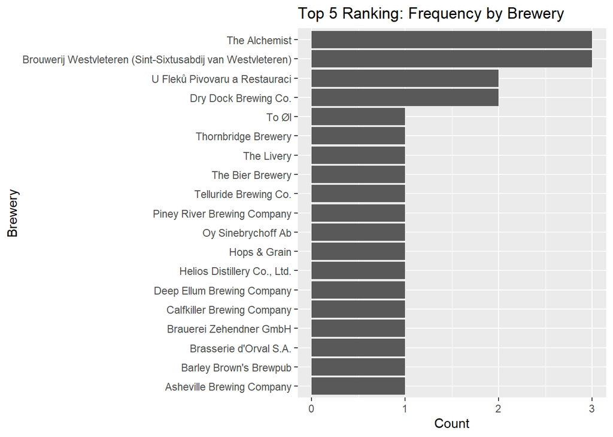

We notice how a few breweries in the overall ranking do not score within the top 5 by any other metrics: Helios Distillery Co. and Brauerei Zehendner GmbH. We also notice the relative dominance of breweries The Alchemist and Brouwerij Westvleteren, which ranked 3rd and 5th on the overall ranking, respectively.

### How does the IBU score affect the overall score?

#### What is IBU?

IBU stands for International Bitterness Unit, and it is a scale used to quantify the bitterness of beer. The IBU scale measures the amount of bittering compounds, primarily iso-alpha acids, derived from hops in the beer. These compounds contribute to the bitterness of the beer.

The IBU scale typically ranges from 0 to 100 or more, with higher values indicating a more bitter taste.

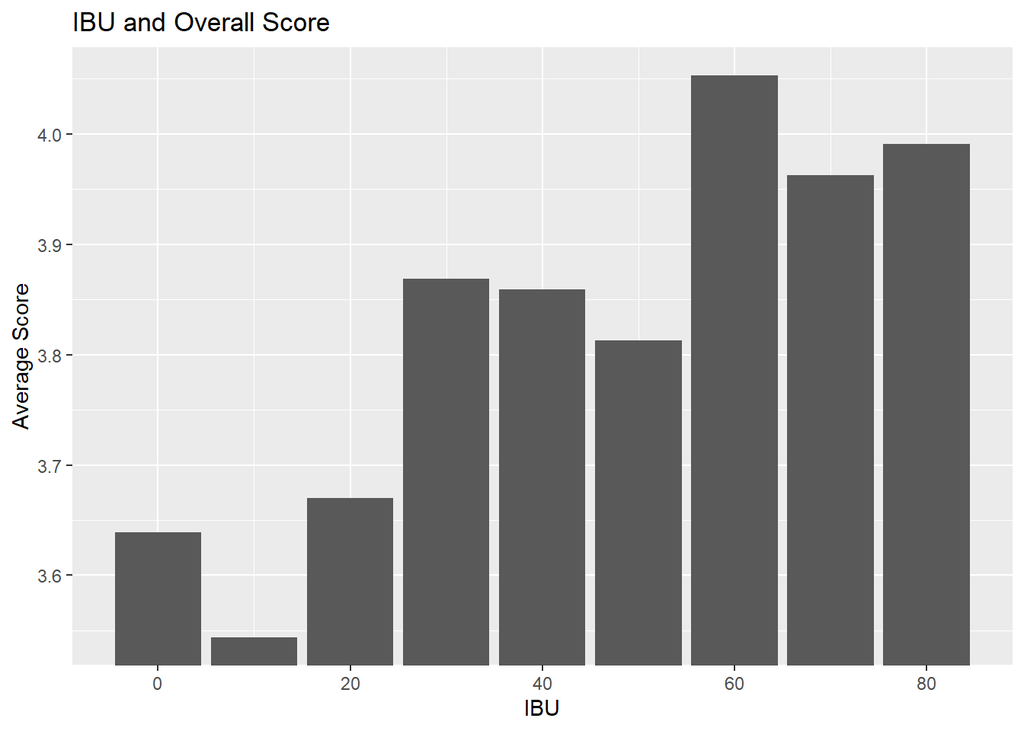

A histogram plotting the average rating per IBU bin demonstrates that there exists an “ideal” and “least ideal” IBU range, those being 60-69 and 10-19, respectively. The graph also indicates a positive correlation between IBU and average score, in general.

### Can we predict the rating of a beer based on its characteristics?

#### Linear Regression Model

```r
features <- data[, c("Sweet", "Bitter", "Sour", "Salty", "Fruits", "Hoppy", "Spices", "Malty", "review_overall")]

# Split data into training and testing sets
set.seed(123)
training_rows <- createDataPartition(features$review_overall, p = 0.8, list = FALSE)
train_data <- features[training_rows, ]
test_data <- features[-training_rows, ]

# Linear Model
model <- lm(review_overall ~ Sweet + Bitter + Sour + Salty + Fruits + Hoppy + Spices + Malty, data = train_data)

summary(model)
```

```
##
## Call:
## lm(formula = review_overall ~ Sweet + Bitter + Sour + Salty +
##     Fruits + Hoppy + Spices + Malty, data = train_data)
##
## Residuals:
##      Min       1Q   Median       3Q      Max
## -2.44386 -0.19584  0.04724  0.25051  1.36407
##
## Coefficients:
##               Estimate Std. Error t value Pr(>|t|)
## (Intercept)  3.2958661  0.0233260 141.296  < 2e-16 ***
## Sweet       -0.0011201  0.0003892  -2.878  0.00403 **
## Bitter       0.0043145  0.0005827   7.404 1.79e-13 ***
## Sour         0.0017782  0.0003807   4.670 3.16e-06 ***
## Salty       -0.0046576  0.0038213  -1.219  0.22302
## Fruits       0.0035742  0.0005083   7.032 2.61e-12 ***
## Hoppy       -0.0011367  0.0004241  -2.681  0.00740 **
## Spices       0.0020623  0.0003617   5.702 1.32e-08 ***
## Malty        0.0023470  0.0003627   6.472 1.16e-10 ***
## ---
## Signif. codes:  0 '***' 0.001 '**' 0.01 '*' 0.05 '.' 0.1 ' ' 1
##
## Residual standard error: 0.4046 on 2551 degrees of freedom
## Multiple R-squared:  0.1913, Adjusted R-squared:  0.1887
## F-statistic: 75.41 on 8 and 2551 DF,  p-value: < 2.2e-16
```

```r
# Make predictions on the test set
predictions <- predict(model, test_data)

# Calculate Root Mean Squared Error
rmse <- sqrt(mean((predictions - test_data$review_overall)^2))
print(paste("Root Mean Squared Error:", rmse))
```

```
## [1] "Root Mean Squared Error: 0.380790631670015"
```

### Interpretation of Linear Regression Statistics:

All of the categories except salty had an extremely low p-value (<0.05) which means that 7 out of the 8 characteristics are statistical significant when predicting the overall review. I am going to rank them by significance and leave out salty due to the p-value.

- 1. Bitter (0.0043145): Bitter had the highest positive influence on the overall review. This indicates that consumers generally lean towards the bitter flavor in beer.
- 2. Fruits (0.0035742): Fruitiness is also a significant predictor. Beers that have a fruity character are generally reviewed more favorably.
- 3. Malty (0.0023470): This characteristic has a positive influence on the overall review. Beers with higher malty flavors are more likely to be rated higher, suggesting a strong preference for maltiness.
- 4. Spices (0.0020623): Spiciness is the fourth most influential factor. A greater presence of spices in beer is associated with higher reviews.
- 5. Sour (0.0017782): Sourness has a positive influence on beer reviews. This suggests that beers with higher levels of sourness tend to be rated slightly more favorably.
- 6. Hoppy (-0.0011367): Hoppiness has a slightly negative influence. Beers with pronounced hop flavors tend to receive poorer reviews.
- 7. Sweet (-0.0011201): Sweetness shows a negative impact on ratings. Beers that are perceived as too sweet tend to be rated lower, indicating a possible aversion to excessive sweetness.

I have decided to dive deeper into three of the categories to get a better understanding of how they affect beer ratings. I am choosing ‘Bitter’, ‘Fruits’, and ‘Malty’ as my characteristics to investigate further because they have the highest affect on overall ratings.

### Bitter

#### Summary Statistics

```r
bitter_stats <- summary(data$Bitter)
bitter_stats
```

```
##    Min. 1st Qu.  Median    Mean 3rd Qu.    Max.
##    0.00   17.00   31.00   36.36   52.00  150.00
```

#### Plots

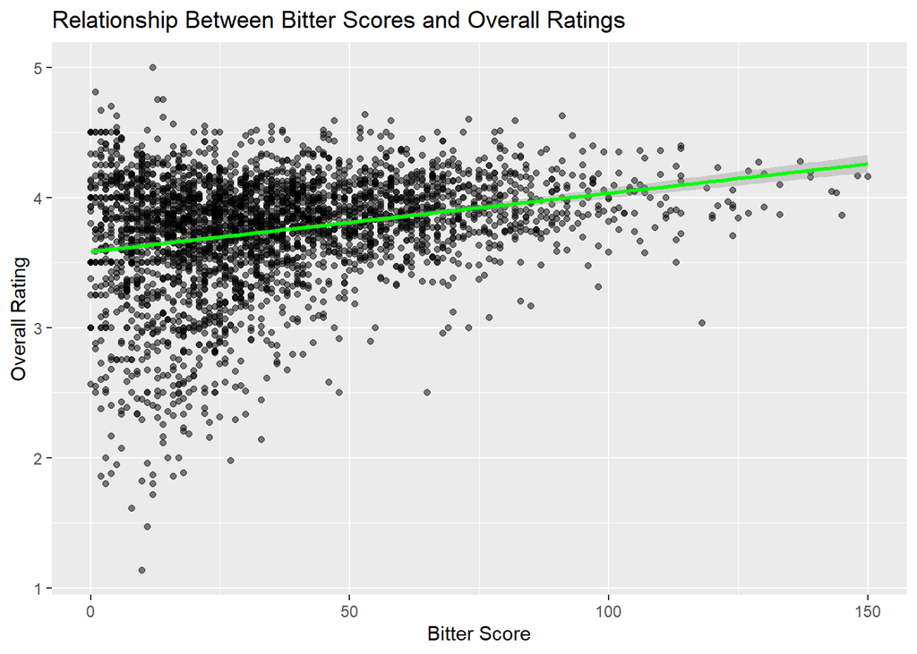

```r
ggplot(data, aes(x = Bitter, y = review_overall)) +
  geom_point(alpha = 0.5) +
  geom_smooth(method = "lm", color = "green") +
  labs(title = "Relationship Between Bitter Scores and Overall Ratings",
       x = "Bitter Score",
       y = "Overall Rating")
```

#### Predicting Example

```r
# Linear regression with bitter as the predictor
bitter_regression <- lm(review_overall ~ Bitter, data = data)

# Predicting the rating for a beer with a bitter score of 120 (high)
predicted_rating_bitter <- predict(bitter_regression, newdata = data.frame(Bitter = 120))
predicted_rating_bitter
```

```
##        1
## 4.123373
```

```r
# Predicting the rating for a beer with a bitter score of 3 (low)
predicted_rating_bitter_2 <- predict(bitter_regression, newdata = data.frame(Bitter = 3))
predicted_rating_bitter_2
```

```
##        1
## 3.597585
```

### Fruits

#### Summary Statistis

```r
fruits_stats <- summary(data$Fruits)
fruits_stats
```

```
##    Min. 1st Qu.  Median    Mean 3rd Qu.    Max.
##    0.00   12.00   29.00   38.53   60.00  175.00
```

#### Plots

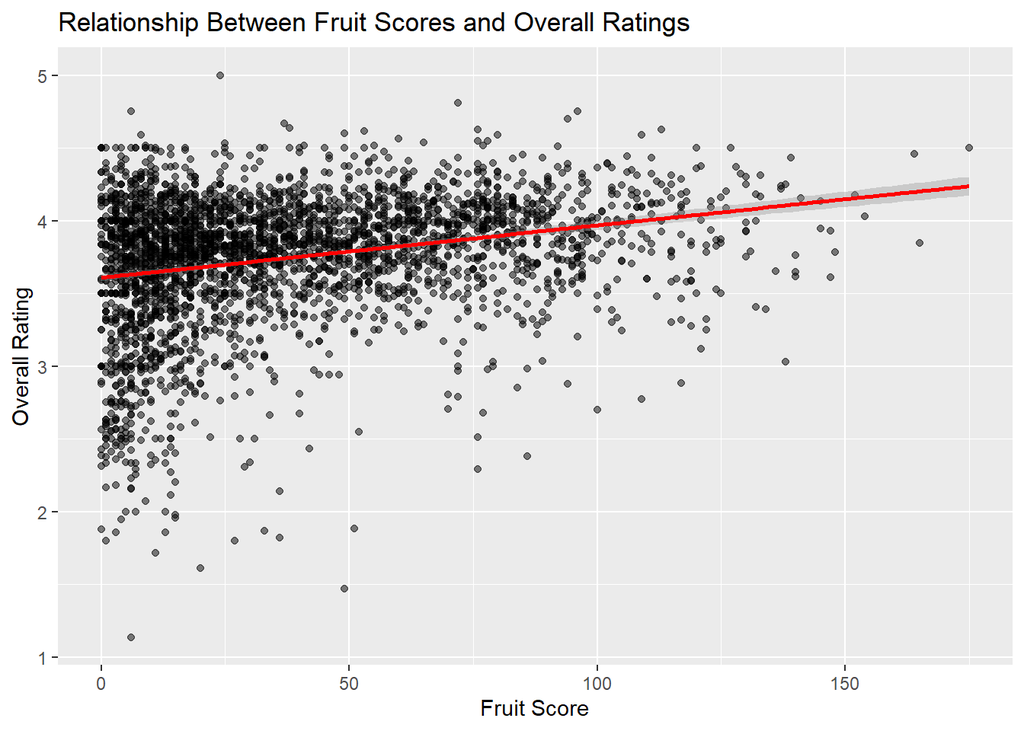

```r
ggplot(data, aes(x = Fruits, y = review_overall)) +
  geom_point(alpha = 0.5) +
  geom_smooth(method = "lm", color = "red") +
  labs(title = "Relationship Between Fruit Scores and Overall Ratings",
       x = "Fruit Score",
       y = "Overall Rating")
```

#### Predicting Example

```r
# Linear regression with fruit as the predictor
fruits_regression <- lm(review_overall ~ Fruits, data = data)

# Predicting the rating for a beer with a fruit score of 110 (high)
predicted_rating_fruits <- predict(fruits_regression, newdata = data.frame(Fruits = 110))
predicted_rating_fruits
```

```
##        1
## 4.004628
```

```r
# Predicting the rating for a beer with a fruit score of 3 (low)
predicted_rating_fruits_2 <- predict(fruits_regression, newdata = data.frame(Fruits = 3))
predicted_rating_fruits_2
```

```
##        1
## 3.619709
```

### Malty

#### Summary Statistics

```r
malty <- summary(data$Malty)
malty
```

```
##    Min. 1st Qu.  Median    Mean 3rd Qu.    Max.
##    0.00   45.00   73.00   75.33  103.00  239.00
```

#### Plots

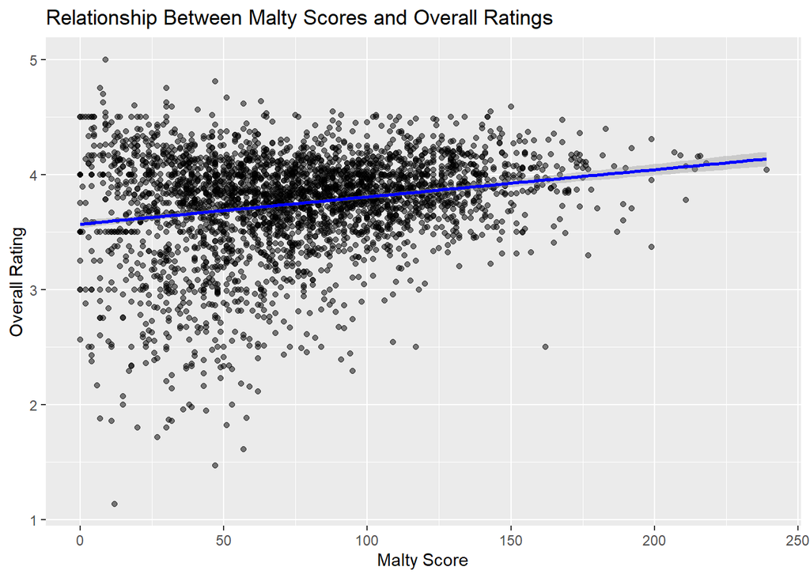

```r
ggplot(data, aes(x = Malty, y = review_overall)) +
  geom_point(alpha = 0.5) +
  geom_smooth(method = "lm", color = "blue") +
  labs(title = "Relationship Between Malty Scores and Overall Ratings",
       x = "Malty Score",
       y = "Overall Rating")
```

#### Predicting Example

```r
# Linear regression with malty as the predictor
malty_regression <- lm(review_overall ~ Malty, data = data)

# Predicting the rating for a beer with a malty score of 200 (very high)
predicted_rating_malty <- predict(malty_regression, newdata = data.frame(Malty = 200))
predicted_rating_malty
```

```
##        1
## 4.043124
```

```r
#Predicting the rating for a beer with a malty score of 30 (very low).
predicted_rating_malty_2 <- predict(malty_regression, newdata = data.frame(Malty = 30))
predicted_rating_malty_2
```

```
##        1
## 3.640038
```

### Which beers have the highest aroma, appearance, palate, and taste ratings?

Top 10 Aroma Rated Beers

| Name | Aroma Rating |
| --- | --- |
| Alt-eration Ale | 5.000000 |
| Jonge Lambik | 5.000000 |
| Oude Lambik | 5.000000 |
| De Troch Oude Gueuze | 4.750000 |
| Pseudo Sue | 4.750000 |
| Rodenbach Caractère Rouge | 4.750000 |
| Pliny The Younger | 4.723770 |
| Framboos | 4.700000 |
| Heady Topper | 4.660981 |
| Pliny The Elder | 4.612188 |

Top 10 Appearance Rated Beers

| Name | Appearance Rating |
| --- | --- |
| Roggenbier | 4.666667 |
| Blåbær Lambik | 4.644231 |
| Naughty 90 | 4.625000 |
| Lambik (2 Year Old Unblended) | 4.625000 |
| The Abyss | 4.593484 |
| Hunahpu’s Imperial Stout | 4.587413 |
| Darkness | 4.543344 |
| Duvel | 4.512857 |
| Steel Wheels ESB | 4.500000 |
| Eis Instigator | 4.500000 |

Top 10 Palate Rated Beers

| Name | Palate Rating |
| --- | --- |
| Oude Lambik | 5.000000 |
| Lambik (2 Year Old Unblended) | 4.750000 |
| Saxonator Dunkles Doppelbock | 4.666667 |
| Roggenbier | 4.666667 |
| Trappist Westvleteren 12 (XII)Brouwerij Westvleteren (Sint-Sixtusabdij van Westvleteren) | 4.633255 |
| Naughty 90 | 4.625000 |
| Pliny The Younger | 4.612295 |
| BBADL (Bourbon Barrel Aged Dark Lord Imperial Stout) | 4.605634 |
| CBS (Canadian Breakfast Stout) | 4.579278 |
| The Abyss | 4.513102 |

Top 10 Taste Rated Beers

| Name | Taste Rating |
| --- | --- |
| Ten FIDY - Bourbon Barrel Aged | 5.000000 |
| Sang Noir | 4.923077 |
| Lambik (2 Year Old Unblended) | 4.875000 |
| Naughty 90 | 4.750000 |
| Framboos | 4.750000 |
| De Troch Oude Gueuze | 4.750000 |
| Rodenbach Caractère Rouge | 4.750000 |
| Pliny The Younger | 4.724590 |
| Trappist Westvleteren 12 (XII)Brouwerij Westvleteren (Sint-Sixtusabdij van Westvleteren) | 4.718553 |
| CBS (Canadian Breakfast Stout) | 4.697017 |

### What are the most common characteristics of beer?

The following characteristics are defined by word counts found in up to 25 reviews of each beer. The assumption is that people writing reviews are more than likely describing what they do experience rather than what they do not. (Refer to the file Beer Descriptors Simplified to see the list of words that are used to calculate the values contained in each of the feature columns below)

(Mouthfeel) 9 - Astringency 10 - Body 11 - Alcohol

(Taste) 12 - Bitter 13 - Sweet 14 - Sour 15 - Salty

(Flavor And Aroma) 16 - Fruits 17 - Hoppy 18 - Spices 19 - Malty

Characteristic Frequencies

| Characteristic | Frequency |
| --- | --- |
| Malty | 240833 |
| Sweet | 186292 |
| Body | 147476 |
| Hoppy | 130836 |
| Fruits | 123179 |
| Bitter | 116257 |
| Sour | 105966 |
| Spices | 58651 |
| Alcohol | 54528 |
| Astringency | 52801 |
| Salty | 3252 |

Q: Which combination of mouth feel, taste, and flavor/aroma characteristics returns the highest ratings?

```
##   review_overall %Bitter  %Sweet   %Sour  %Salty %Fruits  %Hoppy %Spices
## 1       3.847082 0.12948 0.20386 0.09091 0.00000 0.09091 0.15702 0.02204
## 2       4.034304 0.12741 0.21236 0.06178 0.00000 0.09266 0.13514 0.04633
## 3       3.830239 0.18584 0.19027 0.04867 0.00000 0.04425 0.23894 0.01770
## 4       4.005435 0.12020 0.25831 0.04604 0.00256 0.12532 0.10230 0.04092
## 5       3.817708 0.15942 0.16304 0.03261 0.00362 0.03986 0.18478 0.07246
## 6       4.230159 0.13731 0.18507 0.07463 0.00299 0.10149 0.17910 0.01194
##    %Malty
## 1 0.30579
## 2 0.32432
## 3 0.27434
## 4 0.30435
## 5 0.34420
## 6 0.30746
```

```
##    review_overall Bitter Sweet Sour Salty Fruits Hoppy Spices Malty
## 1        5.000000     12    21   48     0     24    15      2     9
## 2        4.807692      1    47   98     0     72     3     19    47
## 3        4.750000     13     8    6     0      6    14      5     7
## 4        4.750000     14    49  200     7     96     8     14    30
## 5        4.700000      4    97   95     0     94     8      0     8
## 6        4.666667      2    37   39     0     37     4     16    51
## 7        4.634615     53    37   38     1     38    77     20    63
## 8        4.628205      5    99  119     0    113    12      0     8
## 9        4.625800     91    40   55     0     76   117      2    30
## 10       4.617925     14    86   21     0     53     5     12    57
```

Data visualized by percent of variable of sum of all variables by raw values.

Reading the boxes as heat maps it can be understood how the score of a drinks overall_review can be predicted with mixtures of flavors.

This shows significance in %’s.

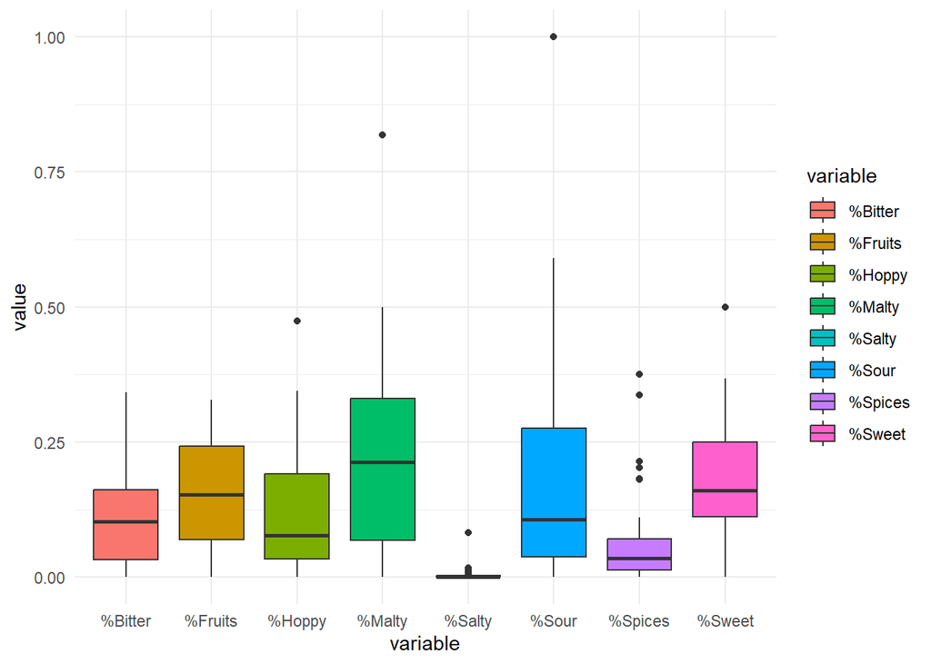

```r
limited_percents_flavor_data <- limited_percents_flavor_data[order(limited_percents_flavor_data$review_overall), ]

limited_percents_flavor_data %>%
    tidyr::gather(variable, value, -review_overall) %>%
    ggplot(aes(x = variable, y = value, fill = variable)) +
        geom_boxplot() +
        theme_minimal()
```

This shows significance in raw amount in drinks.

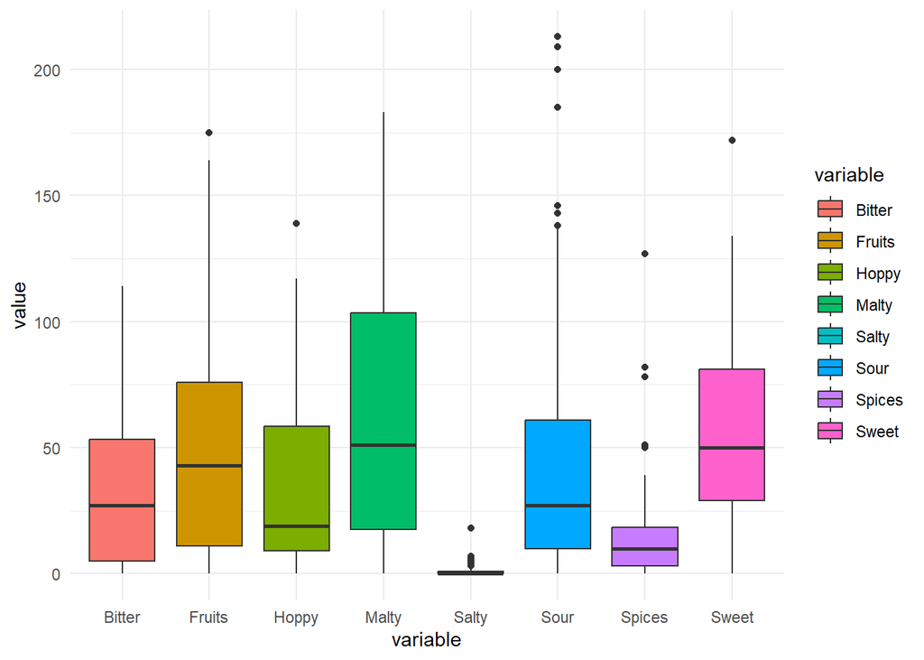

Q: Can we find what characteristics will likely cause a beer to be rated highly?

We will determine flavor significance by creating perfect drinks with specific values being of the best.

First a model must be created.

```r
flavor_model <- lm(review_overall ~ Bitter + Sweet + Sour + Salty + Fruits + Hoppy + Spices + Malty, data = flavor_data)

summary(flavor_model)
```

```
##
## Call:
## lm(formula = review_overall ~ Bitter + Sweet + Sour + Salty +
##     Fruits + Hoppy + Spices + Malty, data = flavor_data)
##
## Residuals:
##      Min       1Q   Median       3Q      Max
## -2.44719 -0.19805  0.04464  0.24981  1.49662
##
## Coefficients:
##               Estimate Std. Error t value Pr(>|t|)
## (Intercept)  3.2946723  0.0206552 159.508  < 2e-16 ***
## Bitter       0.0042459  0.0005192   8.178 4.14e-16 ***
## Sweet       -0.0011467  0.0003440  -3.333 0.000868 ***
## Sour         0.0018913  0.0003386   5.586 2.52e-08 ***
## Salty       -0.0047536  0.0035039  -1.357 0.174989
## Fruits       0.0033067  0.0004493   7.361 2.32e-13 ***
## Hoppy       -0.0009298  0.0003790  -2.454 0.014199 *
## Spices       0.0021207  0.0003138   6.758 1.65e-11 ***
## Malty        0.0023783  0.0003183   7.472 1.02e-13 ***
## ---
## Signif. codes:  0 '***' 0.001 '**' 0.01 '*' 0.05 '.' 0.1 ' ' 1
##
## Residual standard error: 0.3999 on 3188 degrees of freedom
## Multiple R-squared:  0.1919, Adjusted R-squared:  0.1899
## F-statistic: 94.62 on 8 and 3188 DF,  p-value: < 2.2e-16
```

Prime drinks are created with a specific flavor being of the best reviewed drink, then the rest of the values are average of all other drinks.

```r
flavors <- c('Bitter', 'Sweet', 'Sour', 'Salty', 'Fruits', 'Hoppy', 'Spices', 'Malty', 'Base')

for (flavor in flavors) {
  new_prime_flavor <- create_prime_flavor(flavor)
  new_prime_flavor$Flavor <- flavor
  prime_flavors <- rbind(prime_flavors, new_prime_flavor)
}

head(prime_flavors, 9)
```

```
##   review_overall  Bitter    Sweet     Sour    Salty   Fruits    Hoppy   Spices
## 1             NA 12.0000 58.27088 33.14545 1.017204 38.52956 40.92462 18.34564
## 2             NA 36.3644 21.00000 33.14545 1.017204 38.52956 40.92462 18.34564
## 3             NA 36.3644 58.27088 48.00000 1.017204 38.52956 40.92462 18.34564
## 4             NA 36.3644 58.27088 33.14545 0.000000 38.52956 40.92462 18.34564
## 5             NA 36.3644 58.27088 33.14545 1.017204 24.00000 40.92462 18.34564
## 6             NA 36.3644 58.27088 33.14545 1.017204 38.52956 15.00000 18.34564
## 7             NA 36.3644 58.27088 33.14545 1.017204 38.52956 40.92462  2.00000
## 8             NA 36.3644 58.27088 33.14545 1.017204 38.52956 40.92462 18.34564
## 9             NA 36.3644 58.27088 33.14545 1.017204 38.52956 40.92462 18.34564
##      Malty Flavor
## 1 75.33094 Bitter
## 2 75.33094  Sweet
## 3 75.33094   Sour
## 4 75.33094  Salty
## 5 75.33094 Fruits
## 6 75.33094  Hoppy
## 7 75.33094 Spices
## 8  9.00000  Malty
## 9 75.33094   Base
```

```
##   review_overall  Bitter    Sweet     Sour    Salty   Fruits    Hoppy   Spices
## 1       3.644072 12.0000 58.27088 33.14545 1.017204 38.52956 40.92462 18.34564
## 2       3.790260 36.3644 21.00000 33.14545 1.017204 38.52956 40.92462 18.34564
## 3       3.775616 36.3644 58.27088 48.00000 1.017204 38.52956 40.92462 18.34564
## 4       3.752357 36.3644 58.27088 33.14545 0.000000 38.52956 40.92462 18.34564
## 5       3.699477 36.3644 58.27088 33.14545 1.017204 24.00000 40.92462 18.34564
## 6       3.771627 36.3644 58.27088 33.14545 1.017204 38.52956 15.00000 18.34564
## 7       3.712858 36.3644 58.27088 33.14545 1.017204 38.52956 40.92462  2.00000
## 8       3.589769 36.3644 58.27088 33.14545 1.017204 38.52956 40.92462 18.34564
##      Malty Flavor
## 1 75.33094 Bitter
## 2 75.33094  Sweet
## 3 75.33094   Sour
## 4 75.33094  Salty
## 5 75.33094 Fruits
## 6 75.33094  Hoppy
## 7 75.33094 Spices
## 8  9.00000  Malty
```

Flavor significance can be understood by height difference in review scores of better than average flavors being the best ingredient.

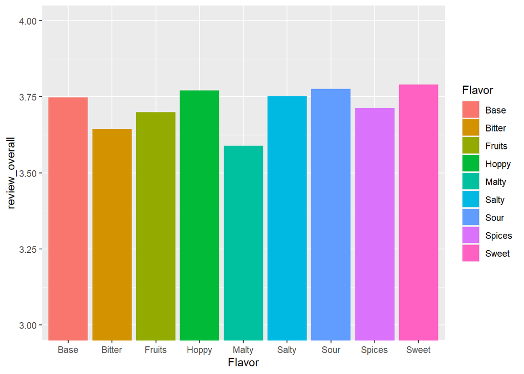

What are the most popular beer styles?

```
## # A tibble: 1 × 2
##   Style             Avg_Review
##   <chr>                  <dbl>
## 1 IPA - New England       4.44
```

```
## # A tibble: 1 × 2
##   Style               Avg_Review
##   <chr>                    <dbl>
## 1 Lager - Malt Liquor       2.48
```

```
## # A tibble: 15 × 2
##    Style                            Avg_Review
##    <chr>                                 <dbl>
##  1 IPA - New England                      4.44
##  2 Wild Ale                               4.23
##  3 Stout - American Imperial              4.18
##  4 Lambic - Traditional                   4.14
##  5 IPA - Imperial                         4.09
##  6 Pale Ale - American                    4.09
##  7 IPA - American                         4.08
##  8 Stout - Russian Imperial               4.06
##  9 Farmhouse Ale - Saison                 4.05
## 10 Porter - Imperial                      4.05
## 11 Lager - Kellerbier / Zwickelbier       4.04
## 12 Brett Beer                             4.03
## 13 Bière de Champagne / Bière Brut        4.03
## 14 Stout - Oatmeal                        4.02
## 15 Lambic - Gueuze                        4.00
```

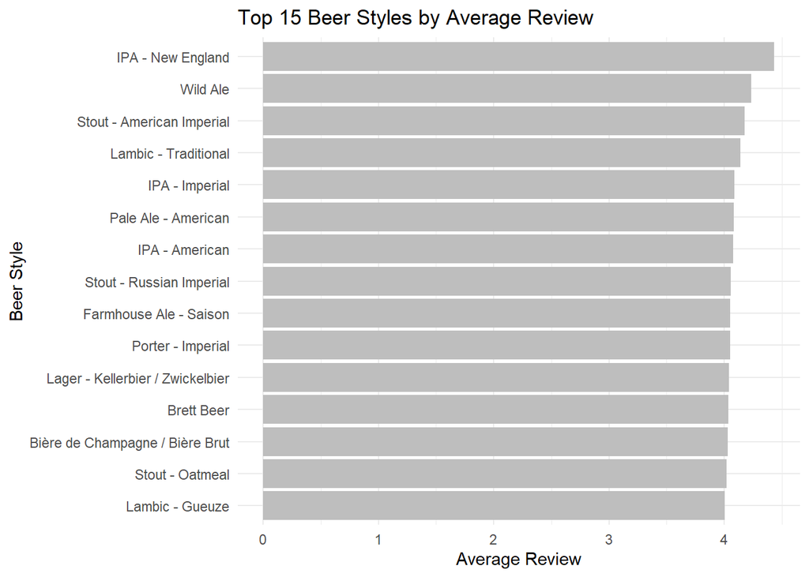

```
## # A tibble: 15 × 2
##    Style                        Avg_Review
##    <chr>                             <dbl>
##  1 Lager - Malt Liquor                2.48
##  2 Low Alcohol Beer                   2.61
##  3 Lager - Light                      2.74
##  4 Lager - European Strong            2.85
##  5 Lager - Adjunct                    3.00
##  6 Lager - Japanese Rice              3.15
##  7 Lager - European Pale              3.18
##  8 Chile Beer                         3.29
##  9 Kvass                              3.30
## 10 Happoshu                           3.31
## 11 Lager - American                   3.36
## 12 Lager - American Amber / Red       3.53
## 13 Cream Ale                          3.53
## 14 Lager - European Dark              3.54
## 15 Lambic - Faro                      3.55
```

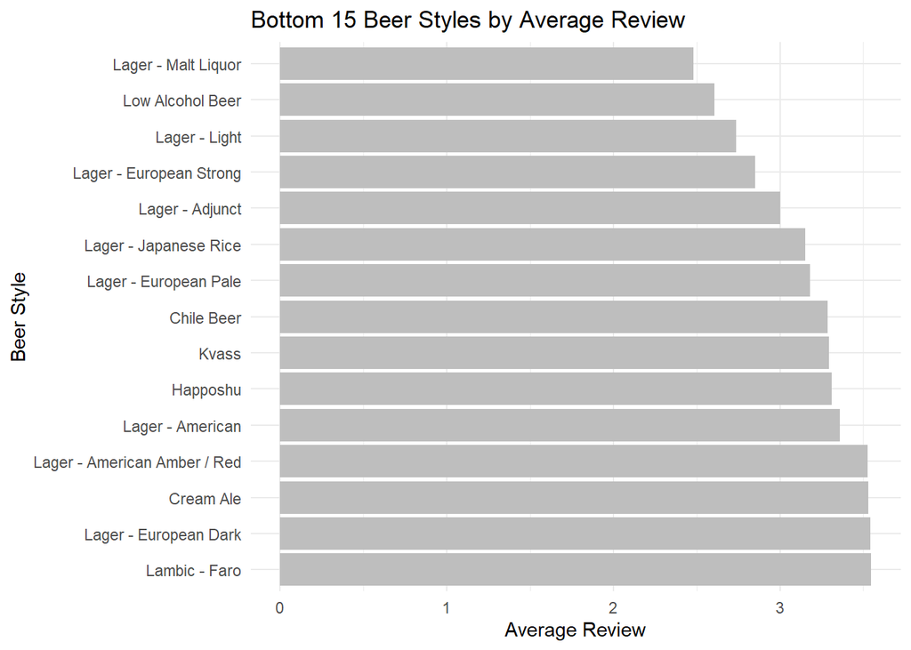

Can we recommend other beers if someone picks a beer they like?

```
## [1] 0.000000000 0.000000000 0.003802281 0.003802281 0.005182246
##          Sweet       Sour
## 2672 0.1634981 0.03873239
## 2686 0.1634981 0.03873239
## 1396 0.1673004 0.03873239
## 526  0.1596958 0.03873239
## 1066 0.1673004 0.03521127
##       Sweet       Sour
## 3 0.1634981 0.03873239
##                                                                Name
## 2671                                                  Oatmeal Stout
## 2685                                        Ohio City Oatmeal Stout
## 1395                                    Dog Bite High Gravity Lager
## 525                                         Mountain Goat Steam Ale
## 1065 Original Honey Brown Extra Rich Lager (Beer Brewed With Honey)
```

[output cut: 36 more lines]

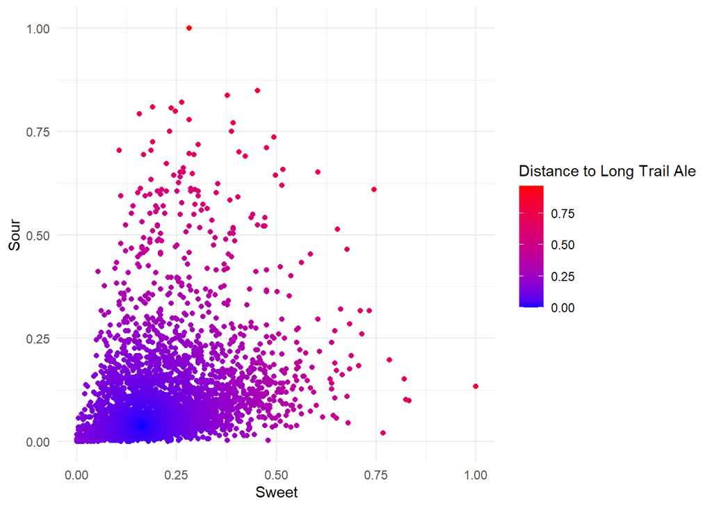

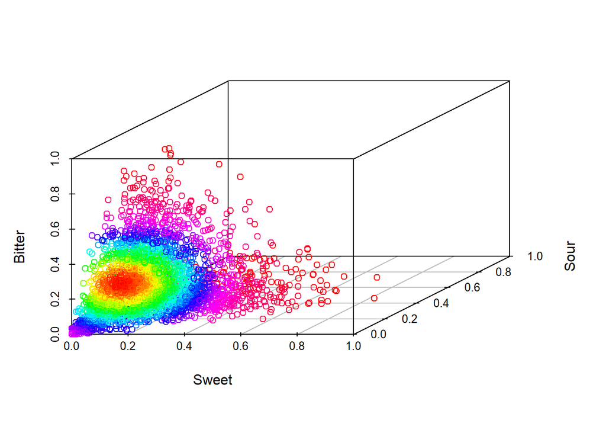

```
##                        Name    Bitter     Sweet       Sour      Salty
## 4            Long Trail Ale 0.3133333 0.3840304 0.06338028 0.02083333
## 1141    Loose Caboose Lager 0.2533333 0.1444867 0.04577465 0.00000000
## 1074          Rickard's Red 0.2533333 0.1444867 0.05281690 0.02083333
## 1093 Dundee Irish Red Lager 0.2866667 0.1368821 0.03873239 0.00000000
## 1282        Stiegl Goldbräu 0.2533333 0.1406844 0.04577465 0.02083333
## 1107    Simpler Times Lager 0.2666667 0.1216730 0.05985915 0.00000000
##          Fruits     Hoppy      Spices     Malty   Distance
## 4    0.28000000 0.2325581 0.086956522 0.4979079         NA
## 1141 0.06857143 0.3081395 0.027173913 0.2468619 0.03838814
## 1074 0.05714286 0.3023256 0.027173913 0.2635983 0.04344189
## 1093 0.06857143 0.2965116 0.021739130 0.2970711 0.05104633
## 1282 0.08571429 0.3372093 0.021739130 0.2468619 0.05683235
## 1107 0.08000000 0.2965116 0.005434783 0.2050209 0.08015352
```